# Práctica 4 - Excel y más gráficos

AE

24/7/2018

## Importando más bases de datos

Ya importamos datos desde el formato “dbf”. Muchas veces construimos nuestra bases de datos desde excel. Vamos a trabajar con una base por Estados, con indicadores que dan cuenta de la competitividad estatal. Vamos instalar la librerìa “readxl”

```r
install.packages("readxl", repos = "http://cran.us.r-project.org", dependencies = TRUE)
```

```
##
##   There is a binary version available but the source version is
##   later:
##        binary source needs_compilation
## readxl  1.0.0  1.1.0              TRUE
```

```
## installing the source package 'readxl'
```

Llamamos la librería

```r
library(readxl)
```

¡Recuerda poner el directorio!

```r
setwd("/Users/anaescoto/Dropbox/DGAPA/2018/RMD")
```

Luego aplicamos el comando. Es de la siguiente forma. Nota que en el el paréntesis va el directorio donde tenemos nuestro archivo. (La base se puede descargar desde [aquí](https://www.dropbox.com/s/1e6hevsv17bozzg/Excel_2014_IMCO.xlsx?dl=0) )

```r
Excel_2014_IMCO <- read_excel("Excel_2014_IMCO.xlsx")
#View(Excel_2014_IMCO)
```

¿Cómo qué tipo de objeto nos importa este comando?

```r
class(Excel_2014_IMCO)
```

```
## [1] "tbl_df"     "tbl"        "data.frame"
```

Ya revisamos análisis descriptivo para algunas variables nominales u ordinales. Vamos a hacer algunos gráficos para variables cuantitativas. #Histograma básico

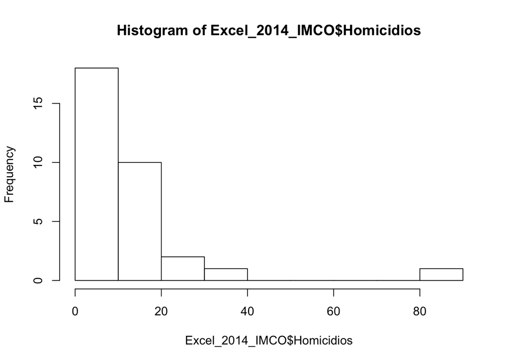

```r
hist(Excel_2014_IMCO$Homicidios)
```

Podemos modificarlo de a poco a poco. Modificar el título

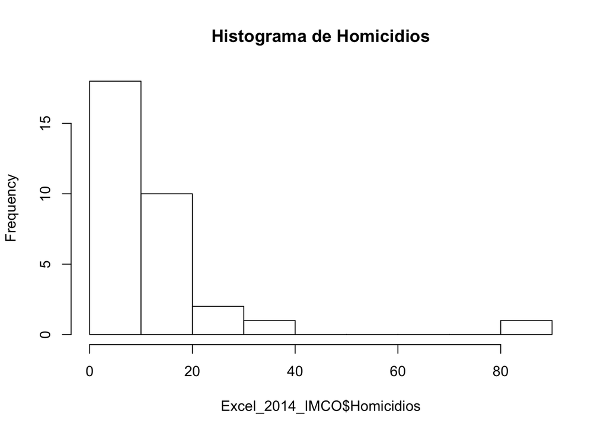

```r
hist(Excel_2014_IMCO$Homicidios, main="Histograma de Homicidios") #Histograma de homicidios en los estados con el título “Histograma de homicidos”
```

Le podemos modificar el título del eje de las x y de las y

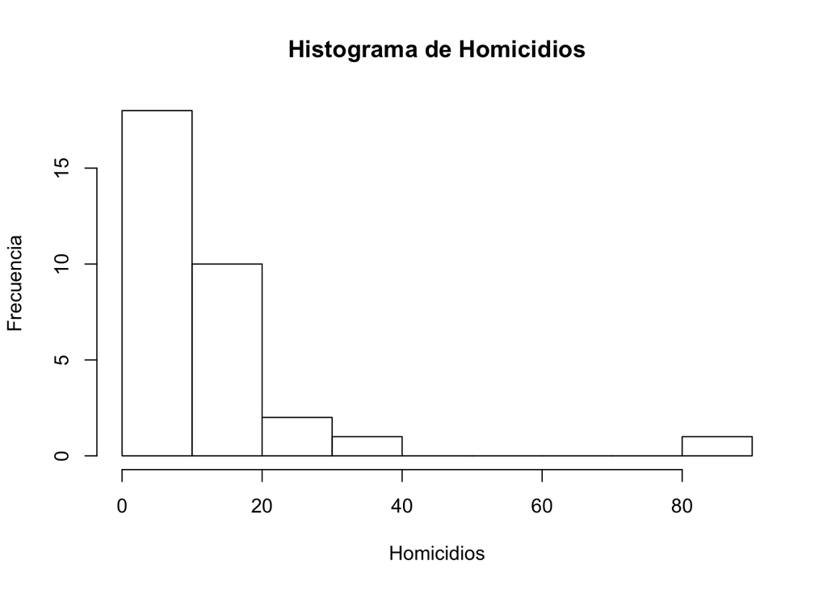

```r
hist(Excel_2014_IMCO$Homicidios, main="Histograma de Homicidios", xlab="Homicidios", ylab="Frecuencia")
```

¡A ponerle colorcitos! Recuerda aquí hay una lista http://www.stat.columbia.edu/~tzheng/files/Rcolor.pdf

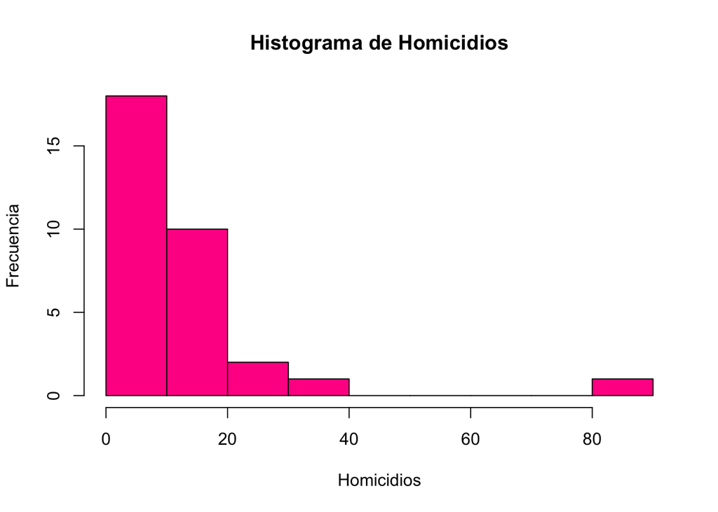

```r
hist(Excel_2014_IMCO$Homicidios, main="Histograma de Homicidios", xlab="Homicidios", ylab="Frecuencia", col="deeppink1")
```

Notamos que hay una agrupación de estados con menos de 40 homicidios por cada 100,000 habitantes.

Hagamos histogramas de otras variables

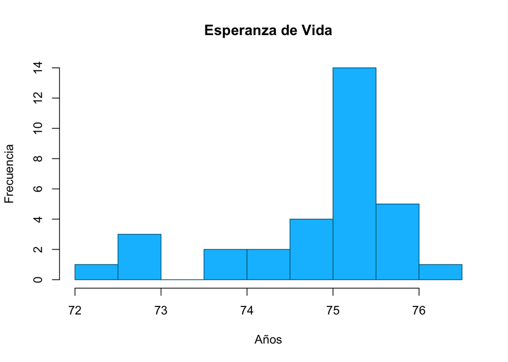

```r
hist(Excel_2014_IMCO$`Esperanza de vida`, main="Esperanza de Vida", xlab="Años", ylab="Frecuencia", col="deepskyblue", border ="deepskyblue4" )
```

¿Algo diferente? Cuando hay espacios en el nombre de nuestras variables en un dataframe, tenemos que ponerlo dentro de estos símbolos ``

# ggplot <3

Hoy vamos a presentar a un gran paquete ¡Es de los famosos! Y tiene más de diez años. https://qz.com/1007328/all-hail-ggplot2-the-code-powering-all-those-excellent-charts-is-10-years-old/

Hay dos funciones en paquete ggplot2

qplot() – para “quick plots”, gráficos rápidos. Nos vamos a concentrar en este curso en estos.  
ggplot() – Para controlar de manera “granular” todo lo de nuestros gráficos.

Más info de qplot http://ggplot2.org/book/qplot.pdf

Vamos a empezar, como siempre, instalando el comando

```r
install.packages("ggplot2", repos = "http://cran.us.r-project.org", dependencies = TRUE)
```

```
##
##   There are binary versions available but the source versions are
##   later:
##         binary source needs_compilation
## vdiffr   0.2.1  0.2.3              TRUE
## ggplot2  2.2.1  3.0.0             FALSE
```

```
## installing the source packages 'vdiffr', 'ggplot2'
```

```r
library(ggplot2)
```

# Univariado

Podemos hacer histogramas y gráficos de densidad

El comando tiene la siguiente form

qplot (VAR, dara = NombreDataframe, geom=“histogram”) qplot (VAR, dara = NombreDataframe, geom=“density”)

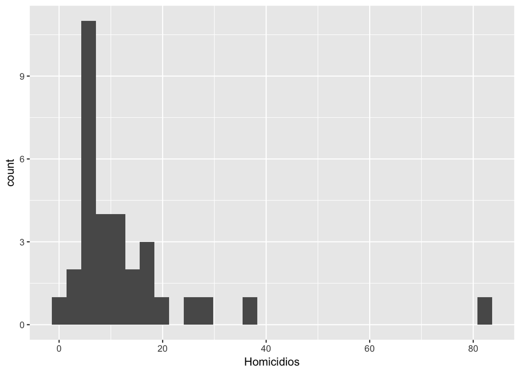

```r
qplot(Homicidios, data = Excel_2014_IMCO, geom = "histogram")
```

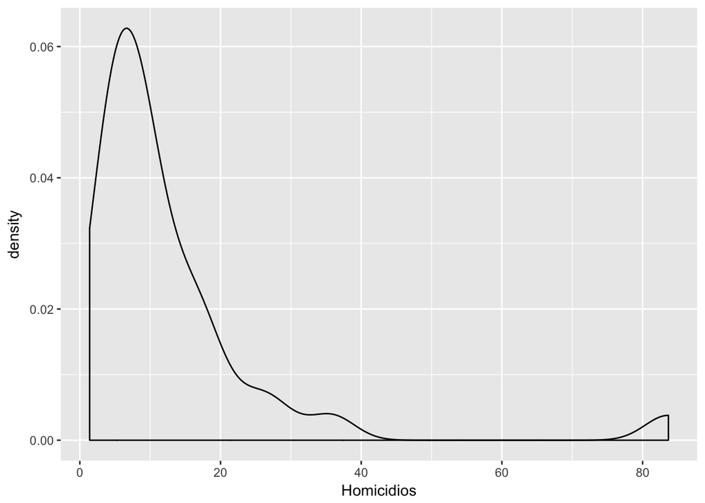

```r
qplot(Homicidios, data = Excel_2014_IMCO, geom = "density")
```

# Bivariado

Checa: en este comando, como usamos la opción de “data”, no tenemos que poner el nombre del data frame antes de la variable.

El formato es el siguiente:

qplot(VariableX, VariableY, data = NombreDataframe)

En nuestro ejemplo queda así:

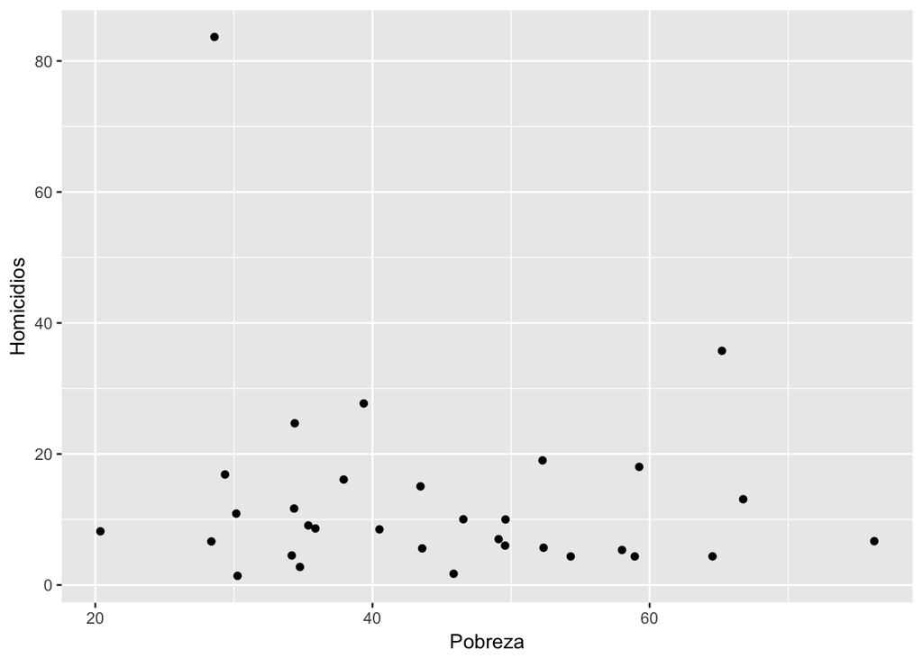

```r
qplot(Pobreza, Homicidios, data = Excel_2014_IMCO)
```

Una transformación importante en los análisis cuantitativos es la transformación logarítmica

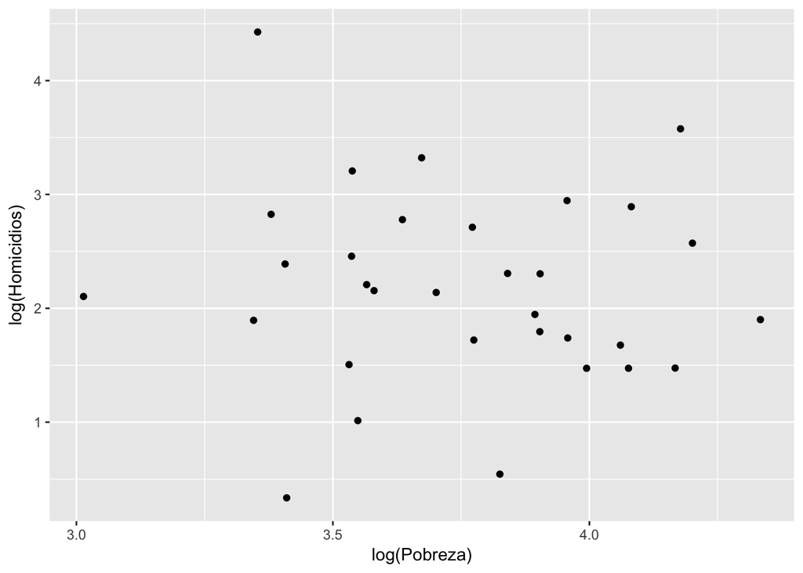

```r
qplot(log(Pobreza), log(Homicidios), data = Excel_2014_IMCO)
```

# Guardando nuestro gráfico como un objeto

```r
grafico<-qplot(log(Pobreza), log(Homicidios), data = Excel_2014_IMCO)
```

# Theme Assist Addins

Existe un add-in - es decir un complemento - para que podamos modificar más fácilmente los gr´áficos que hacemos con ggplot. Lo tenemos que instalar. Así como hemos instalado nuestros otras paqueter´ías.

```r
install.packages("ggThemeAssist", repos = "http://cran.us.r-project.org", dependencies = TRUE)
library(ggThemeAssist)
```

Para utilizarlo, tenemos que nombrar el objeto que queremos editar (por eso aprendimos a guardarlo en un objeto anteriormente). Lo escribimos. Lo seleccionamos y buscamos el complemento en la pestaña “Addins”

[figure not shown]

# Complicando las cosas (nomás tantito)

Vamos hoy a establecer las regiones para evidenciar subgrupos en nuestros estados.

```r
Excel_2014_IMCO$region<-NA
```

Vamos a hacer vectores de cada región

```r
noroeste<-c("Baja California","Baja California Sur", "Chihuahua", "Durango","Sinaloa", "Sonora")
noreste<- c("Coahuila", "Nuevo León", "Tamaulipas")
occidente <-c("Colima", "Jalisco", "Michoacán", "Nayarit")
oriente <- c("Hidalgo", "Puebla","Tlaxcala", "Veracruz")
centronorte<-c("Aguascalientes", "Guanajuato", "Querétaro", "San Luis Potosí", "Zacatecas")
centrosur<- c("Ciudad de México", "México",  "Morelos")
suroeste <-c("Campeche", "Quintana Roo", "Tabasco","Yucatán")
sureste <- c("Chiapas", "Guerrero", "Oaxaca")
```

**Mi primer loop**

R puede hacer loop con el comando for Nos permite repetir una operación de acuerdo a los valores de una secuencia o de un vector. Aquí lo hacemos para el vector noroeste

```r
for(i in noroeste) {
  reg<-i
  Excel_2014_IMCO$region[Excel_2014_IMCO$edo==reg] <- "Noroeste"
}
```

Lo hacemos para el resto de regiones

```r
for(i in noreste) {
  reg<-i
  Excel_2014_IMCO$region[Excel_2014_IMCO$edo==reg] <- "Noreste"
}

for(i in occidente) {
  reg<-i
  Excel_2014_IMCO$region[Excel_2014_IMCO$edo==reg] <- "Occidente"
}

for(i in oriente) {
  reg<-i
  Excel_2014_IMCO$region[Excel_2014_IMCO$edo==reg] <- "Oriente"
}
for(i in centrosur) {
  reg<-i
  Excel_2014_IMCO$region[Excel_2014_IMCO$edo==reg] <- "Centro Sur"
}

for(i in centronorte) {
  reg<-i
  Excel_2014_IMCO$region[Excel_2014_IMCO$edo==reg] <- "Centro Norte"
}

for(i in suroeste) {
  reg<-i
  Excel_2014_IMCO$region[Excel_2014_IMCO$edo==reg] <- "Sur oeste"
}

for(i in sureste) {
  reg<-i
  Excel_2014_IMCO$region[Excel_2014_IMCO$edo==reg] <- "Sur Este"
}
```

Con subgrupos podemos agregar otra variable en nuestro gráficos

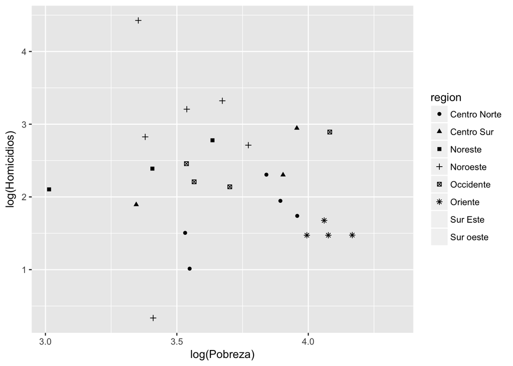

```r
q1<-qplot(log(Pobreza), log(Homicidios), data = Excel_2014_IMCO, shape = region)
q1
```

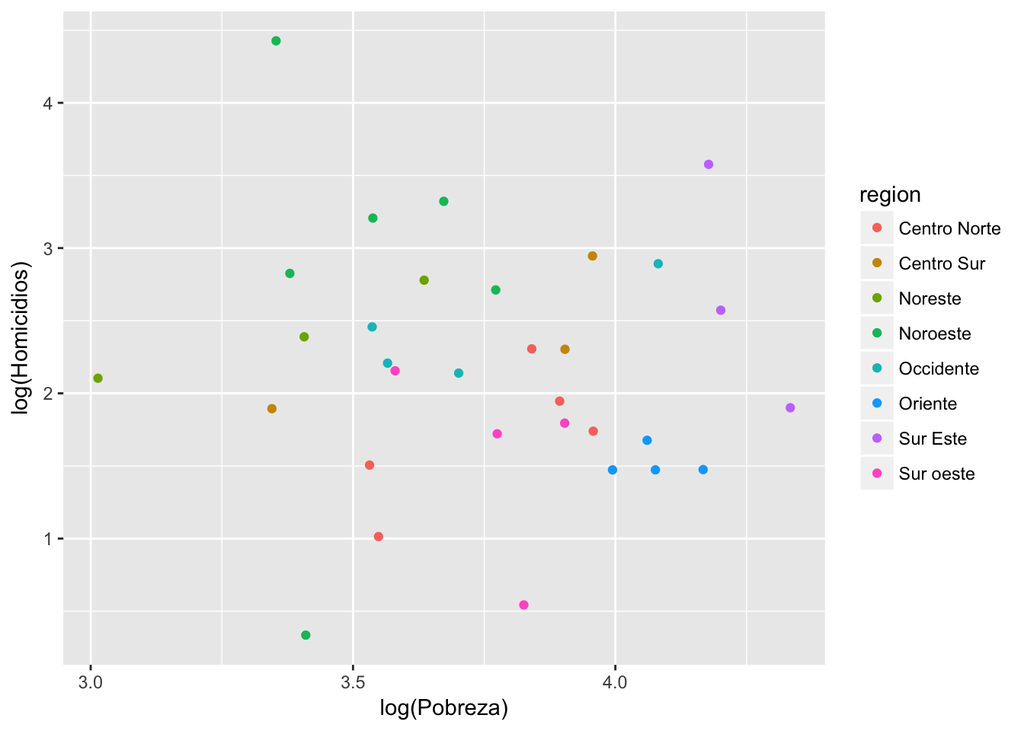

```r
q2<-qplot(log(Pobreza), log(Homicidios), data = Excel_2014_IMCO, colour = region)
q2
```

Con una regresión lineal

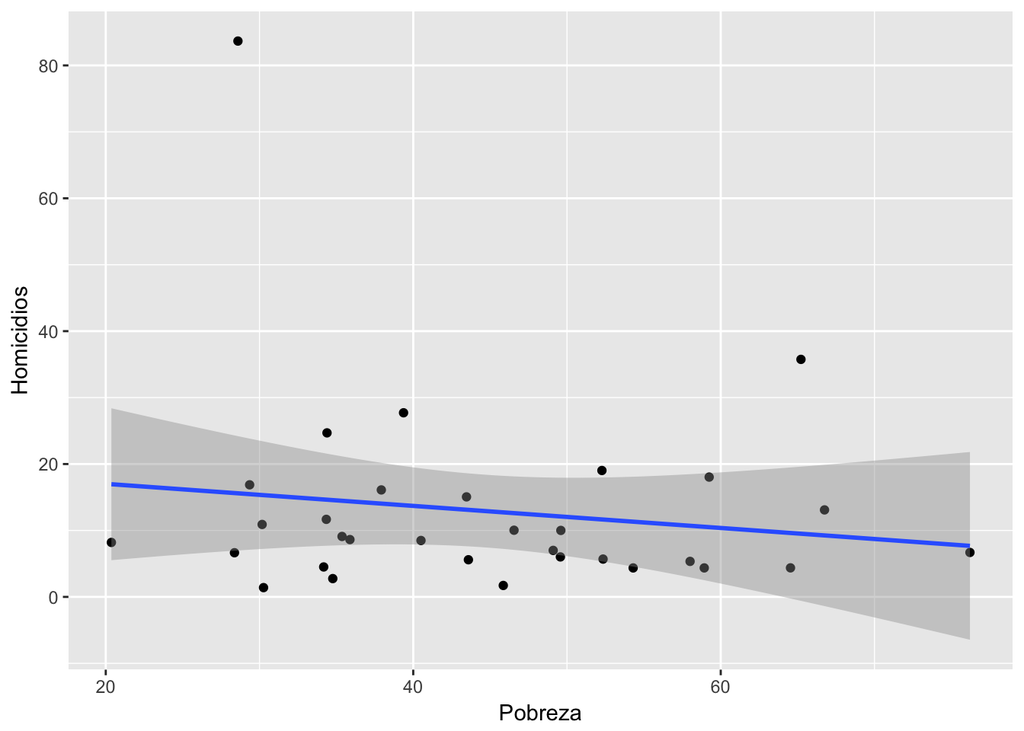

```r
q3<-qplot(Pobreza, Homicidios, data = Excel_2014_IMCO, geom = c("point", "smooth"), method = "lm")
q3
```

Para tener un subgráfico por región

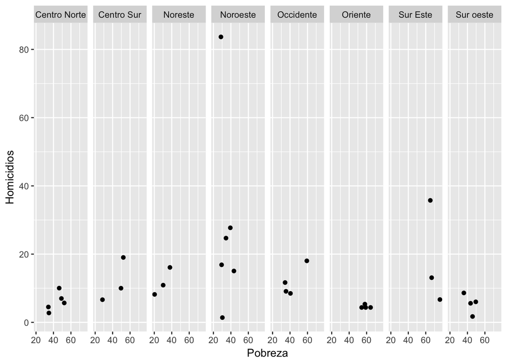

```r
q4<-qplot(Pobreza, Homicidios, data = Excel_2014_IMCO) + facet_grid(. ~ region)
q4
```

# Etiquetas

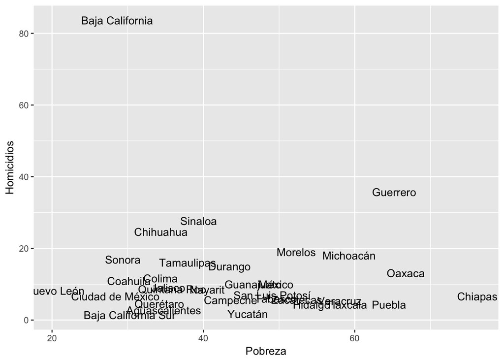

```r
q5<-qplot(Pobreza, Homicidios, data = Excel_2014_IMCO, label=Excel_2014_IMCO$edo, geom="text")
q5
```